# eDNA_exploration_2021

From help documentation - “method gives the contribution of each species to overall dissimilarities, but these are caused by variation in species abundances, and only partly by diff. among groups.”

```r
sim.kelp <- simper(full.kelp, gear.kelp$gear, permutations = 999)
summary(sim.kelp)
```

```
##
## Contrast: beach_seine_eDNA
##
##                             average      sd  ratio    ava    avb cumsum     p
## Clupeidae                  0.051484 0.01206 4.2694 0.0000 1.0000 0.1016 0.002
## Stichaeidae                0.038255 0.02670 1.4330 0.2857 1.0000 0.1772 0.015
## Hexagrammidae              0.030809 0.02884 1.0682 0.8571 0.4286 0.2380 0.032
## Ammodytidae                0.027955 0.02804 0.9970 0.4286 0.7143 0.2932 0.261
## Citharichthys stigmaeus    0.025298 0.02376 1.0646 0.1429 0.5714 0.3431 0.256
## Syngnathus leptorhynchus   0.024297 0.02761 0.8799 0.4286 0.2857 0.3911 0.446
## Gadidae                    0.024051 0.02711 0.8871 0.4286 0.2857 0.4386 0.830
## Salmonidae                 0.023516 0.02882 0.8160 0.5714 1.0000 0.4850 0.135
## Pleuronectidae             0.022988 0.02549 0.9018 0.4286 0.2857 0.5304 0.592
## Sebastidae                 0.022074 0.02794 0.7902 0.7143 0.7143 0.5740 0.880
## Gasterosteus               0.020520 0.02658 0.7721 0.2857 0.2857 0.6145 0.611
## Polypera greeni            0.020005 0.02373 0.8431 0.0000 0.4286 0.6540 0.082
## Blepsias cirrhosus         0.019542 0.02340 0.8350 0.4286 0.0000 0.6926 0.188
## Gobiesox maeandricus       0.019075 0.02286 0.8346 0.0000 0.4286 0.7302 0.104
## Teleostei                  0.017745 0.02094 0.8473 0.0000 0.4286 0.7653 0.145
## Embiotocidae               0.017713 0.02503 0.7077 0.8571 0.7143 0.8003 0.240
## Aulorhynchus flavidus      0.016404 0.02358 0.6955 0.2857 0.1429 0.8326 0.538
## Nautichthys oculofasciatus 0.015094 0.02132 0.7081 0.1429 0.2857 0.8624 0.719
## Rhinogobiops nicholsii     0.014803 0.02450 0.6042 0.2857 0.0000 0.8917 0.375
## Agonidae                   0.012928 0.02109 0.6131 0.2857 0.0000 0.9172 0.431
## Anoplopoma fimbria         0.011520 0.01858 0.6199 0.0000 0.2857 0.9399 0.215
## Cottidae                   0.009624 0.02410 0.3993 1.0000 0.8571 0.9589 0.055
## Ronquilus jordani          0.008189 0.02081 0.3935 0.1429 0.0000 0.9751 0.760
## Clupidae                   0.007315 0.01850 0.3955 0.1429 0.0000 0.9895 0.810
## Rhamphocottus richardsonii 0.005295 0.01315 0.4026 0.0000 0.1429 1.0000 0.291
## Pholidae                   0.000000 0.00000    NaN 1.0000 1.0000 1.0000 1.000
## Citharichthys sordidus     0.000000 0.00000    NaN 0.0000 0.0000 1.0000 1.000
## Lepidogobius lepidus       0.000000 0.00000    NaN 0.0000 0.0000 1.0000 1.000
## Brosmophycis marginata     0.000000 0.00000    NaN 0.0000 0.0000 1.0000 1.000
## Liparis fucensis           0.000000 0.00000    NaN 0.0000 0.0000 1.0000 1.000
##
## Clupeidae                  **
## Stichaeidae                *
## Hexagrammidae              *
## Ammodytidae
## Citharichthys stigmaeus
```

[output cut: 14 more lines]

```
## Agonidae
## Anoplopoma fimbria
## Cottidae                   .
## Ronquilus jordani
## Clupidae
## Rhamphocottus richardsonii
## Pholidae
## Citharichthys sordidus
## Lepidogobius lepidus
## Brosmophycis marginata
## Liparis fucensis
## ---
## Signif. codes:  0 '***' 0.001 '**' 0.01 '*' 0.05 '.' 0.1 ' ' 1
## Permutation: free
## Number of permutations: 999
```

We can also look at species that are significantly correlated with the nmds axes. Because it looks like the variability between gear type falls along the first axis can look at what species drive that separation of gear type

```r
# create df of scores across some variable (habitat or habitat richness, year, julian etc)
scrs2 <- as.data.frame(scores(kelp.nmds, display = 'sites'))
scrs2 <- cbind(as.data.frame(scrs2), gear = gear.kelp$gear)
cent2 <- aggregate(cbind(NMDS1, NMDS2) ~ gear, data =scrs2, FUN = mean)
segs2 <- merge(scrs2, setNames(cent2, c('gear', 'oNMDS1', 'oNMDS2')),
              by = "gear", sort = FALSE)

# create species vectors correlated w/ nmds axis - untransformed data
vec.sp2 <- envfit(kelp.nmds$points, full.kelp[,1:30], perm = 999)
vec.sp.arrows2 <- scores(vec.sp2, display = "vectors")
vec.sp.dat2 <- data.frame(vec.sp.arrows2)
vec.sp.dat2$pvals <- vec.sp2$vectors$pvals
vec.sp.dat2$sp_code <- row.names(vec.sp.dat2)
vec.sp.dat2$r2 <- vec.sp2$vectors$r

# filter by species that are sig correlated w/ nmds axis
vec.sp.dat.sig2 <- vec.sp.dat2 %>%
  filter(pvals < 0.05)

vec.sp.dat.sig2 <- vec.sp.dat.sig2 %>%
  dplyr::select(MDS1, MDS2, pvals, sp_code, r2)

# scale by nmds?
scalefactor2 <- min(max(scrs2$NMDS1) - min(scrs2$NMDS1), max(scrs2$NMDS2) - min(scrs2$NMDS2))
vec.sp.dat.sig2$MDS1_sc <- vec.sp.dat.sig2$MDS1 * (scalefactor2 * vec.sp.dat.sig2$r2)
vec.sp.dat.sig2$MDS2_sc <- vec.sp.dat.sig2$MDS2 * (scalefactor2 * vec.sp.dat.sig2$r2)
```

Visualize the nmds w/ beach seine eDNA data with species vectors for kelp sites

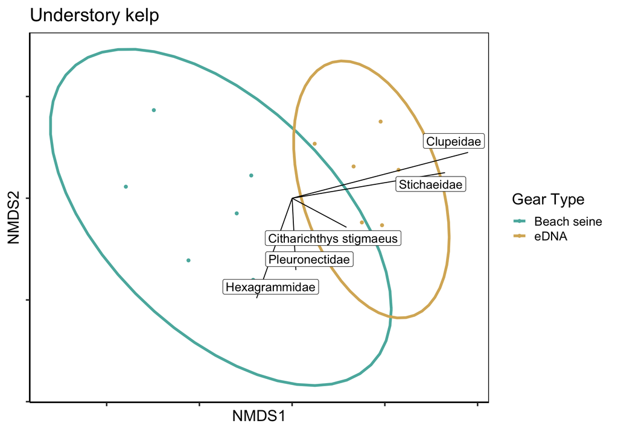

Figure 15: Nonmetric multidimensional scaling of species communities with understory kelp beds. Color represents the gear type used to sample the community - either beach seine or environmental DNA. Species vectors are species that are significnatly correlated with the NMDS axes and length represents the strength of that correlation (r2)